# RCG datacall Report

Compiled on 18/10/2022, 11:20

# 1 Detailed data table

## 1.1 Consistency of age-length relationship

RCG detailed data were checked for the consistency of the age-length data. The Grubbs’ test was performed to evaluate whether the maximum value of age distribution could be considered as outliers. In case, a table reporting the outliers is returned.’

Plot of age-length relationship by year and sex for Merluccius merluccius - ITA - GSA17

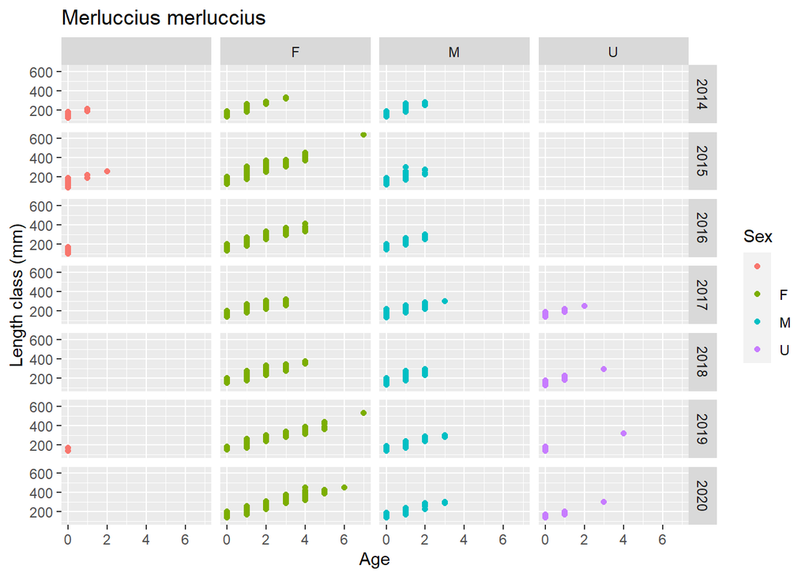

*Table of the age class outliers for Merluccius merluccius in GSA17*

|  | Flag_country | Year | Trip_code | Date | Area | Commercial_size_category | Age | Sex | Length_class | fish_ID |
| --- | --- | --- | --- | --- | --- | --- | --- | --- | --- | --- |
| 556 | ITA | 2015 | 2015OTB2681GSA17 | 17/04/2015 | GSA17 | C | 7 | F | 640 | 5490 |
| 2782 | ITA | 2019 | 2019OTB59GSA17 | 08/05/2019 | GSA17 | C | 7 | F | 530 | 7339 |

## 1.2 Consistency of LFD by year

The consistency of length frequency distributions (LFD) was checked generating a multi-frame plot of the LFD by year. The Grubbs’ test was performed to evaluate whether the minimum and the maximum values of Length class distribution could be considered as outliers. In case, a table reporting the outliers is returned.

Plot of LFDs by year for Merluccius merluccius - ITA - GSA17

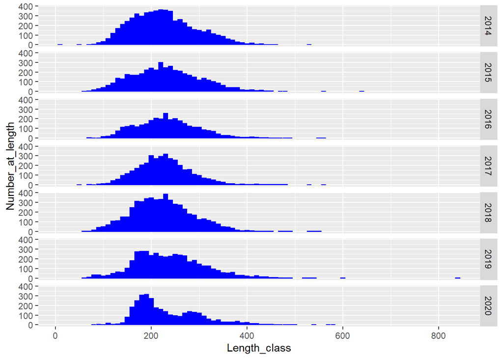

*Outliers of the length distribution for Merluccius merluccius in GSA17*

|  | Flag_country | Year | Trip_code | Date | Area | Commercial_size_category | Age | Sex | Length_class | fish_ID |
| --- | --- | --- | --- | --- | --- | --- | --- | --- | --- | --- |
| 16647 | ITA | 2019 | 2019OTB203GSA17 | 29/09/2019 | GSA17 | C | NA | N | 840 |  |

## 1.3 Consistency of LFD by year and commercial category

The consistency of length frequency distributions (LFD) was checked generating a multi-frame plot of the LFD by year and commercial size categories.

Plot of LFDs by year and commercial size category for Merluccius merluccius - ITA - GSA17

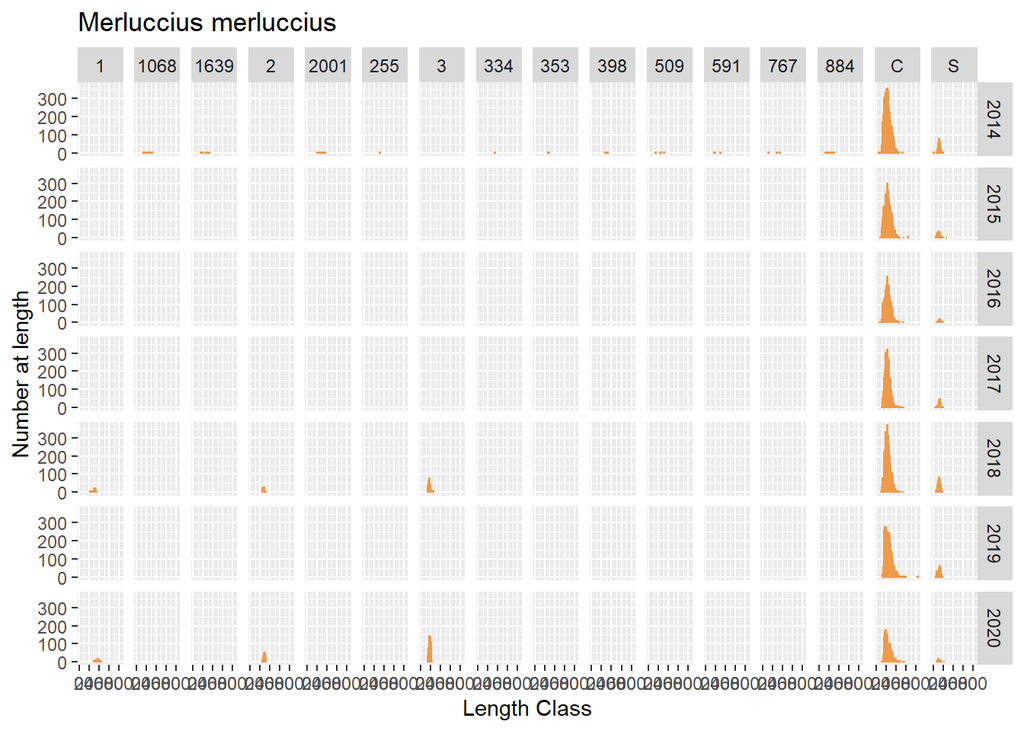

## 1.4 Consistency of length-weight relationship

Plot of length-weight by year and sex for Merluccius merluccius - ITA - GSA17

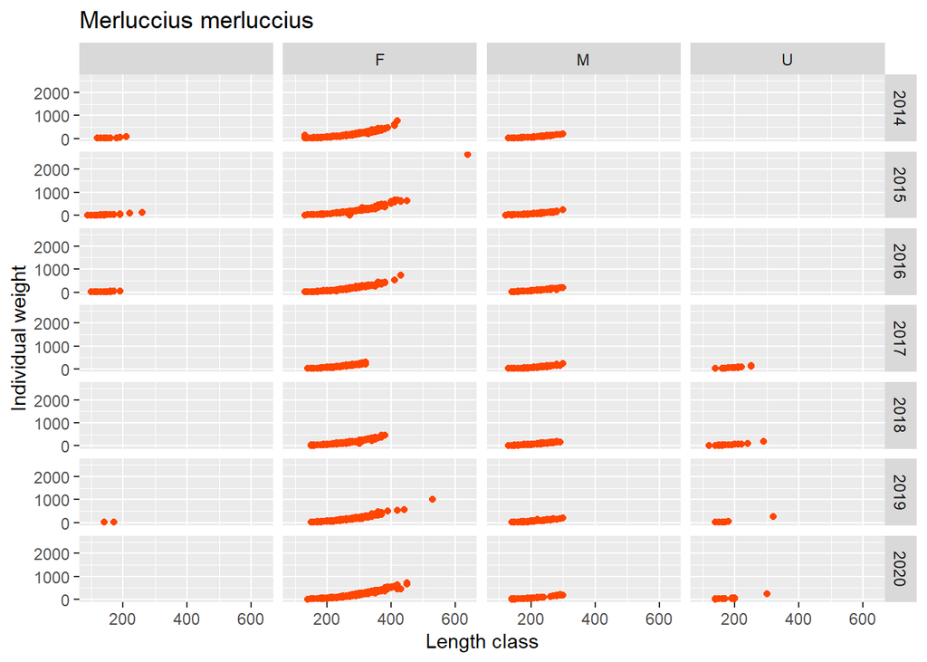

*Outliers of the lengths distribution for Merluccius merluccius in GSA17*

|  | Flag_country | Year | Trip_code | Date | Area | Commercial_size_category | Age | Sex | Length_class | fish_ID |
| --- | --- | --- | --- | --- | --- | --- | --- | --- | --- | --- |
| 556 | ITA | 2015 | 2015OTB2681GSA17 | 17/04/2015 | GSA17 | C | 7 | F | 640 | 5490 |

## 1.5 Consistency of sex and maturity stage

The consistency of maturity stages by sex and year was qualitatively checked accordingly to the length class.

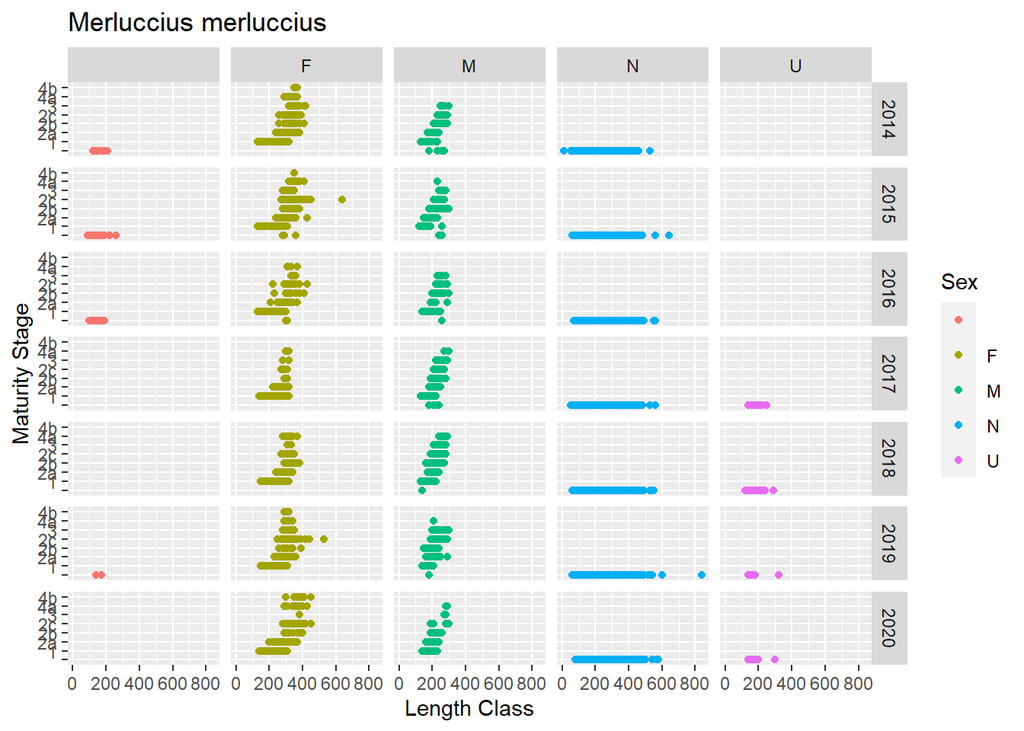

## 1.6 check_mat_ogive

The maturity stages composition was checked estimating the maturity ogives by sex for: Merluccius merluccius.

Plot of maturity ogive of males individuals for: Merluccius merluccius - ITA - GSA17

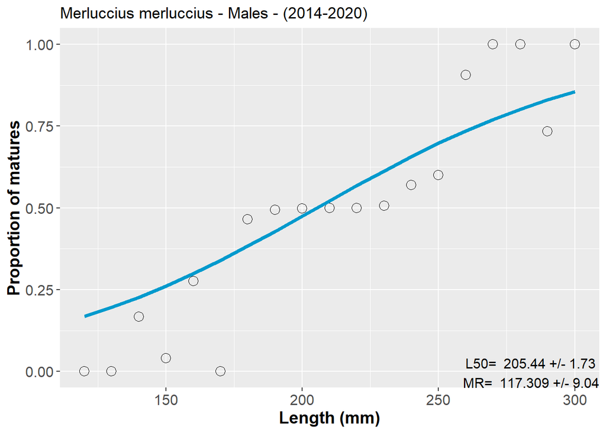

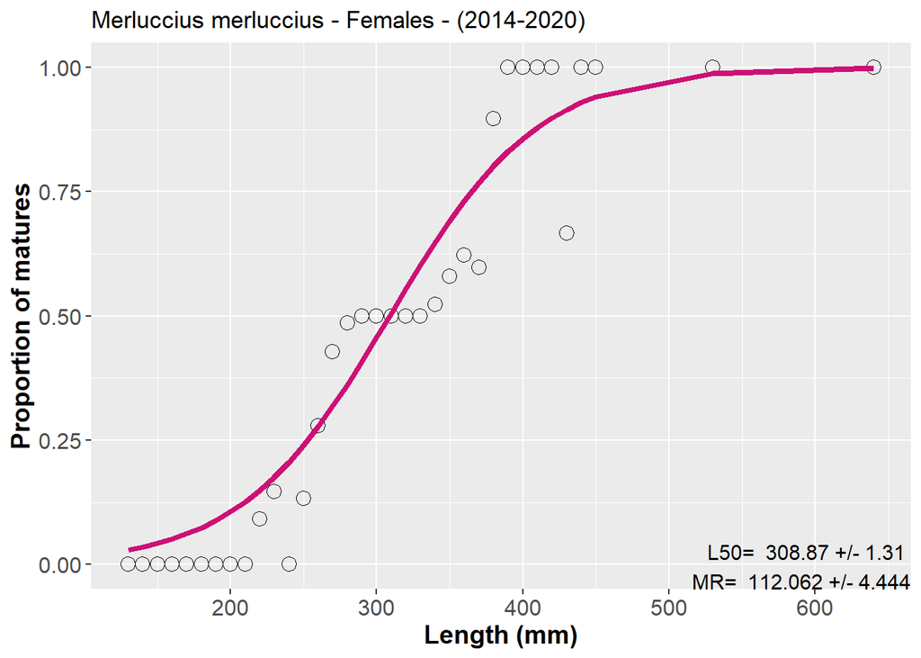

## 1.7 Summary of trips

Biological data were analysed to provide a summary table reporting the number of trips/hauls monitored by year, port, metier and sampling method.

### 1.7.1 GSA17

#### 1.7.1.1 Merluccius merluccius

*Summary table reporting the number of trips/hauls monitored by year by port, metier, sampling method for Merluccius merluccius in GSA17*

| Year | Flag_country | Area | Harbour | Species | Fishing_activity_category_European_lvl_6 | Sampling_method | Nb_trips |
| --- | --- | --- | --- | --- | --- | --- | --- |
| 2014 | ITA | GSA17 | ITAOI | Merluccius merluccius | OTB_DEF_>=40_0_0 | Observer | 28 |
| 2014 | ITA | GSA17 | ITCCL | Merluccius merluccius | OTB_DEF_>=40_0_0 | Observer | 5 |
| 2014 | ITA | GSA17 | ITCHI | Merluccius merluccius | OTB_DEF_>=40_0_0 | Observer | 4 |
| 2014 | ITA | GSA17 | ITCNT | Merluccius merluccius | OTB_DEF_>=40_0_0 | Observer | 2 |
| 2014 | ITA | GSA17 | ITPPT | Merluccius merluccius | OTB_DEF_>=40_0_0 | Observer | 3 |
| 2014 | ITA | GSA17 | ITSDB | Merluccius merluccius | OTB_DEF_>=40_0_0 | Observer | 4 |
| 2015 | ITA | GSA17 | ITAOI | Merluccius merluccius | OTB_DEF_>=40_0_0 | Observer | 19 |
| 2015 | ITA | GSA17 | ITCCL | Merluccius merluccius | OTB_DEF_>=40_0_0 | Observer | 3 |
| 2015 | ITA | GSA17 | ITGUI | Merluccius merluccius | OTB_DEF_>=40_0_0 | Observer | 3 |
| 2015 | ITA | GSA17 | ITPSR | Merluccius merluccius | OTB_DEF_>=40_0_0 | Observer | 2 |
| 2015 | ITA | GSA17 | ITSDB | Merluccius merluccius | OTB_DEF_>=40_0_0 | Observer | 2 |
| 2016 | ITA | GSA17 | ITAOI | Merluccius merluccius | OTB_DEF_>=40_0_0 | Observer | 17 |
| 2016 | ITA | GSA17 | ITCCL | Merluccius merluccius | OTB_DEF_>=40_0_0 | Observer | 3 |
| 2016 | ITA | GSA17 | ITCHI | Merluccius merluccius | OTB_DEF_>=40_0_0 | Observer | 1 |
| 2016 | ITA | GSA17 | ITGUI | Merluccius merluccius | OTB_DEF_>=40_0_0 | Observer | 5 |
| 2016 | ITA | GSA17 | ITPPT | Merluccius merluccius | OTB_DEF_>=40_0_0 | Observer | 2 |
| 2016 | ITA | GSA17 | ITPSR | Merluccius merluccius | OTB_DEF_>=40_0_0 | Observer | 1 |
| 2017 | ITA | GSA17 | ITAOI | Merluccius merluccius | OTB_DEF_>=40_0_0 | Observer | 19 |
| 2017 | ITA | GSA17 | ITCCL | Merluccius merluccius | OTB_DEF_>=40_0_0 | Observer | 7 |
| 2017 | ITA | GSA17 | ITGUI | Merluccius merluccius | OTB_DEF_>=40_0_0 | Observer | 5 |
| 2017 | ITA | GSA17 | ITPPT | Merluccius merluccius | OTB_DEF_>=40_0_0 | Observer | 1 |
| 2017 | ITA | GSA17 | ITSDB | Merluccius merluccius | OTB_DEF_>=40_0_0 | Observer | 3 |
| 2017 | ITA | GSA17 | ITTMI | Merluccius merluccius | OTB_DEF_>=40_0_0 | Observer | 2 |
| 2018 | ITA | GSA17 | ITAOI | Merluccius merluccius | OTB_DEF_>=40_0_0 | Observer | 19 |
| 2018 | ITA | GSA17 | ITCCL | Merluccius merluccius | OTB_DEF_>=40_0_0 | Observer | 5 |
| 2018 | ITA | GSA17 | ITCHI | Merluccius merluccius | OTB_DEF_>=40_0_0 | Observer | 4 |
| 2018 | ITA | GSA17 | ITGUI | Merluccius merluccius | OTB_DEF_>=40_0_0 | Observer | 6 |
| 2018 | ITA | GSA17 | ITPPT | Merluccius merluccius | OTB_DEF_>=40_0_0 | Observer | 4 |
| 2018 | ITA | GSA17 | ITPSR | Merluccius merluccius | OTB_DEF_>=40_0_0 | Observer | 2 |
| 2018 | ITA | GSA17 | ITTMI | Merluccius merluccius | OTB_DEF_>=40_0_0 | Observer | 3 |
| 2019 | ITA | GSA17 | ITAOI | Merluccius merluccius | OTB_DEF_>=40_0_0 | Observer | 19 |
| 2019 | ITA | GSA17 | ITCCL | Merluccius merluccius | OTB_DEF_>=40_0_0 | Observer | 7 |
| 2019 | ITA | GSA17 | ITCHI | Merluccius merluccius | OTB_DEF_>=40_0_0 | Observer | 6 |
| 2019 | ITA | GSA17 | ITGUI | Merluccius merluccius | OTB_DEF_>=40_0_0 | Observer | 8 |
| 2019 | ITA | GSA17 | ITPSR | Merluccius merluccius | OTB_DEF_>=40_0_0 | Observer | 1 |
| 2019 | ITA | GSA17 | ITSDB | Merluccius merluccius | OTB_DEF_>=40_0_0 | Observer | 2 |
| 2020 | ITA | GSA17 | ITAOI | Merluccius merluccius | OTB_DEF_>=40_0_0 | Observer | 11 |
| 2020 | ITA | GSA17 | ITCCL | Merluccius merluccius | OTB_DEF_>=40_0_0 | Observer | 6 |
| 2020 | ITA | GSA17 | ITCHI | Merluccius merluccius | OTB_DEF_>=40_0_0 | Observer | 6 |
| 2020 | ITA | GSA17 | ITGUI | Merluccius merluccius | OTB_DEF_>=40_0_0 | Observer | 12 |

## 1.8 Consistency of trip location

The consistency of trip location was checked plotting the spatial distribution of data using the initial and final coordinates, where available, and the ports position included in the data in case coordinates are not available..

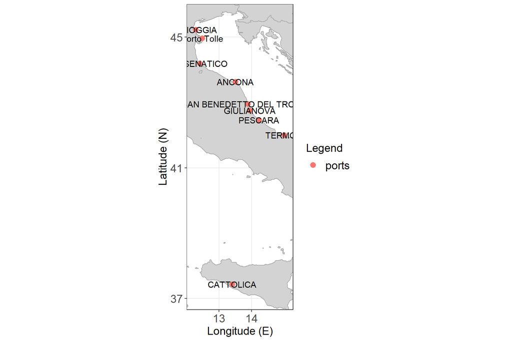

## 1.9 Summary of individual measurements

Biological data were analysed to provide a summary table reporting the number of individual by trip for which biological data have been collected (length, sex, maturity, weight and age)

### 1.9.1 GSA17

#### 1.9.1.1 Merluccius merluccius

*Summary table reporting the number of measurements by trip for each biological variable for Merluccius merluccius in GSA17*

| Year | Area | Species | Trip_code | age_data | length_measurements | maturity_data | sex_data | weight_data |
| --- | --- | --- | --- | --- | --- | --- | --- | --- |
| 2014 | GSA17 | Merluccius merluccius | 2014OTB2380GSA17 | 26 | 227 | 227 | 227 | 37 |
| 2014 | GSA17 | Merluccius merluccius | 2014OTB2384GSA17 | 23 | 84 | 84 | 84 | 38 |
| 2014 | GSA17 | Merluccius merluccius | 2014OTB2387GSA17 | NA | 290 | 290 | 290 | NA |
| 2014 | GSA17 | Merluccius merluccius | 2014OTB2388GSA17 | NA | 93 | 93 | 93 | NA |
| 2014 | GSA17 | Merluccius merluccius | 2014OTB2390GSA17 | 27 | 90 | 90 | 90 | 43 |
| 2014 | GSA17 | Merluccius merluccius | 2014OTB2394GSA17 | NA | 187 | 187 | 187 | NA |
| 2014 | GSA17 | Merluccius merluccius | 2014OTB2397GSA17 | 27 | 92 | 92 | 92 | 42 |
| 2014 | GSA17 | Merluccius merluccius | 2014OTB2402GSA17 | NA | 184 | 184 | 184 | NA |
| 2014 | GSA17 | Merluccius merluccius | 2014OTB2406GSA17 | NA | 217 | 217 | 217 | NA |
| 2014 | GSA17 | Merluccius merluccius | 2014OTB2410GSA17 | NA | 432 | 432 | 432 | NA |
| 2014 | GSA17 | Merluccius merluccius | 2014OTB2413GSA17 | 27 | 96 | 96 | 96 | 45 |
| 2014 | GSA17 | Merluccius merluccius | 2014OTB2416GSA17 | NA | 144 | 144 | 144 | NA |
| 2014 | GSA17 | Merluccius merluccius | 2014OTB2429GSA17 | NA | 226 | 226 | 226 | NA |
| 2014 | GSA17 | Merluccius merluccius | 2014OTB2435GSA17 | 19 | 86 | 86 | 86 | 42 |
| 2014 | GSA17 | Merluccius merluccius | 2014OTB2441GSA17 | NA | 153 | 153 | 153 | NA |
| 2014 | GSA17 | Merluccius merluccius | 2014OTB2457GSA17 | NA | 352 | 352 | 352 | NA |
| 2014 | GSA17 | Merluccius merluccius | 2014OTB2463GSA17 | NA | 98 | 98 | 98 | NA |
| 2014 | GSA17 | Merluccius merluccius | 2014OTB2466GSA17 | 18 | 83 | 83 | 83 | 38 |
| 2014 | GSA17 | Merluccius merluccius | 2014OTB2475GSA17 | NA | 217 | 217 | 217 | NA |
| 2014 | GSA17 | Merluccius merluccius | 2014OTB2525GSA17 | NA | 120 | 120 | 120 | NA |
| 2014 | GSA17 | Merluccius merluccius | 2014OTB2534GSA17 | 21 | 156 | 156 | 156 | 27 |
| 2014 | GSA17 | Merluccius merluccius | 2014OTB2544GSA17 | NA | 141 | 141 | 141 | NA |
| 2014 | GSA17 | Merluccius merluccius | 2014OTB2554GSA17 | NA | 93 | 93 | 93 | NA |
| 2014 | GSA17 | Merluccius merluccius | 2014OTB2563GSA17 | NA | 34 | 34 | 34 | NA |
| 2014 | GSA17 | Merluccius merluccius | 2014OTB2565GSA17 | 24 | 83 | 83 | 83 | 38 |
| 2014 | GSA17 | Merluccius merluccius | 2014OTB2567GSA17 | NA | 1 | 1 | 1 | NA |
| 2014 | GSA17 | Merluccius merluccius | 2014OTB2573GSA17 | NA | 11 | 11 | 11 | NA |
| 2014 | GSA17 | Merluccius merluccius | 2014OTB2577GSA17 | NA | 219 | 219 | 219 | NA |
| 2014 | GSA17 | Merluccius merluccius | 2014OTB2580GSA17 | NA | 235 | 235 | 235 | NA |
| 2014 | GSA17 | Merluccius merluccius | 2014OTB2586GSA17 | NA | 110 | 110 | 110 | NA |

[output cut: 232 more lines]

# 2 Landing data table

## 2.1 Consistency of data in CL table

The consistency of CL table was checked plotting data for temporal, spatial and metier coverage for the given species:

*Sum of Landings by year, quarter and month for Merluccius merluccius in GSA17*

| Year | Quarter | Month | Sum_Landings |
| --- | --- | --- | --- |
| 2014 | 1 | 1 | 171696.53 |
| 2014 | 1 | 2 | 142277.29 |
| 2014 | 1 | 3 | 160227.83 |
| 2014 | 2 | 4 | 149634.21 |
| 2014 | 2 | 5 | 153620.80 |
| 2014 | 2 | 6 | 146757.76 |
| 2014 | 3 | 7 | 163284.95 |
| 2014 | 3 | 8 | 39766.13 |
| 2014 | 3 | 9 | 64826.15 |
| 2014 | 4 | 10 | 196456.86 |
| 2014 | 4 | 11 | 190424.82 |
| 2014 | 4 | 12 | 210234.82 |
| 2015 | 1 | 1 | 216046.03 |
| 2015 | 1 | 2 | 212327.63 |
| 2015 | 1 | 3 | 222710.86 |
| 2015 | 2 | 4 | 214281.86 |
| 2015 | 2 | 5 | 185852.02 |
| 2015 | 2 | 6 | 175540.83 |
| 2015 | 3 | 7 | 200653.11 |
| 2015 | 3 | 8 | 65631.90 |
| 2015 | 3 | 9 | 26839.01 |
| 2015 | 4 | 10 | 163015.31 |
| 2015 | 4 | 11 | 155368.26 |
| 2015 | 4 | 12 | 176815.41 |
| 2016 | 1 | 1 | 166433.07 |
| 2016 | 1 | 2 | 159334.15 |
| 2016 | 1 | 3 | 151847.97 |
| 2016 | 2 | 4 | 159683.80 |
| 2016 | 2 | 5 | 151888.86 |
| 2016 | 2 | 6 | 169606.94 |

[output cut: 54 more lines]

*Sum of Landing value by year, quarter and month for Merluccius merluccius in GSA17*

| Year | Quarter | Month | Sum_LandingsValue |
| --- | --- | --- | --- |
| 2014 | 1 | 1 | 1057607.3 |
| 2014 | 1 | 2 | 1018411.3 |
| 2014 | 1 | 3 | 1092178.1 |
| 2014 | 2 | 4 | 1045062.7 |
| 2014 | 2 | 5 | 1079206.7 |
| 2014 | 2 | 6 | 1040318.7 |
| 2014 | 3 | 7 | 1171439.7 |
| 2014 | 3 | 8 | 273279.0 |
| 2014 | 3 | 9 | 407865.1 |
| 2014 | 4 | 10 | 1173897.7 |
| 2014 | 4 | 11 | 1131975.1 |
| 2014 | 4 | 12 | 1368771.0 |
| 2015 | 1 | 1 | 1302269.3 |
| 2015 | 1 | 2 | 1432435.1 |
| 2015 | 1 | 3 | 1592516.1 |
| 2015 | 2 | 4 | 1552816.6 |
| 2015 | 2 | 5 | 1375128.1 |
| 2015 | 2 | 6 | 1325560.3 |
| 2015 | 3 | 7 | 1379130.0 |
| 2015 | 3 | 8 | 501599.1 |
| 2015 | 3 | 9 | 177775.7 |
| 2015 | 4 | 10 | 1014718.9 |
| 2015 | 4 | 11 | 934410.2 |
| 2015 | 4 | 12 | 1219340.1 |
| 2016 | 1 | 1 | 1197813.0 |
| 2016 | 1 | 2 | 1314828.4 |
| 2016 | 1 | 3 | 1365655.1 |
| 2016 | 2 | 4 | 1375392.2 |
| 2016 | 2 | 5 | 1375431.1 |
| 2016 | 2 | 6 | 1341871.5 |

[output cut: 54 more lines]

*Sum of landings by LandCtry, VslFlgCtry, Area, Rect, SubRect, Harbour for Merluccius merluccius in GSA17*

| LandCtry | VslFlgCtry | Area | Rect | SubRect | Harbour | Sum_Landings |
| --- | --- | --- | --- | --- | --- | --- |
| NA | ITA | GSA17 | NA | NA | NA | 12302665 |

*Sum of landing value by LandCtry, VslFlgCtry, Area, Rect, SubRect, Harbour for Merluccius merluccius in GSA17*

| LandCtry | VslFlgCtry | Area | Rect | SubRect | Harbour | Sum_LandingsValue |
| --- | --- | --- | --- | --- | --- | --- |
| NA | ITA | GSA17 | NA | NA | NA | 89980541 |

*Sum of landings by Year, Species, foCatEu5, foCatEu6 for Merluccius merluccius in GSA17*

| Year | Species | foCatEu5 | foCatEu6 | Sum_Landings |
| --- | --- | --- | --- | --- |
| 2014 | Merluccius merluccius | NA | GTR_DEF_>=16_0_0 | 468.090 |
| 2014 | Merluccius merluccius | NA | OTB_DEF_>=40_0_0 | 1788740.060 |
| 2015 | Merluccius merluccius | NA | GNS_DEF_>=16_0_0 | 3293.030 |
| 2015 | Merluccius merluccius | NA | GTR_DEF_>=16_0_0 | 359.040 |
| 2015 | Merluccius merluccius | NA | OTB_DEF_>=40_0_0 | 2011430.160 |
| 2016 | Merluccius merluccius | NA | GNS_DEF_>=16_0_0 | 8.730 |
| 2016 | Merluccius merluccius | NA | GTR_DEF_>=16_0_0 | 586.290 |
| 2016 | Merluccius merluccius | NA | LLS_DEF_0_0_0 | 105.660 |
| 2016 | Merluccius merluccius | NA | OTB_DEF_>=40_0_0 | 1730675.900 |
| 2017 | Merluccius merluccius | NA | GNS_DEF_>=16_0_0 | 1085.050 |
| 2017 | Merluccius merluccius | NA | GTR_DEF_>=16_0_0 | 333.640 |
| 2017 | Merluccius merluccius | NA | OTB_DEF_>=40_0_0 | 1835684.160 |
| 2018 | Merluccius merluccius | NA | GNS_DEF_>=16_0_0 | 3631.770 |
| 2018 | Merluccius merluccius | NA | GTR_DEF_>=16_0_0 | 23.830 |
| 2018 | Merluccius merluccius | NA | LLS_DEF_0_0_0 | 1175.020 |
| 2018 | Merluccius merluccius | NA | OTB_DEF_>=40_0_0 | 1852369.190 |
| 2019 | Merluccius merluccius | NA | GNS_DEF_>=16_0_0 | 6202.896 |
| 2019 | Merluccius merluccius | NA | GTR_DEF_>=16_0_0 | 264.352 |
| 2019 | Merluccius merluccius | NA | LLS_DEF_0_0_0 | 27095.600 |
| 2019 | Merluccius merluccius | NA | OTB_DEF_>=40_0_0 | 1550566.224 |
| 2020 | Merluccius merluccius | NA | GNS_DEF_>=16_0_0 | 760.650 |
| 2020 | Merluccius merluccius | NA | GTR_DEF_>=16_0_0 | 12.100 |
| 2020 | Merluccius merluccius | NA | LLS_DEF_0_0_0 | 13.000 |
| 2020 | Merluccius merluccius | NA | OTB_DEF_>=40_0_0 | 1487780.750 |

*Sum of landing value by Year, Species, foCatEu5, foCatEu6 for Merluccius merluccius in GSA17*

| Year | Species | foCatEu5 | foCatEu6 | Sum_LandingsValue |
| --- | --- | --- | --- | --- |
| 2014 | Merluccius merluccius | NA | GTR_DEF_>=16_0_0 | 3743.950 |
| 2014 | Merluccius merluccius | NA | OTB_DEF_>=40_0_0 | 11856268.450 |
| 2015 | Merluccius merluccius | NA | GNS_DEF_>=16_0_0 | 19205.360 |
| 2015 | Merluccius merluccius | NA | GTR_DEF_>=16_0_0 | 2871.660 |
| 2015 | Merluccius merluccius | NA | OTB_DEF_>=40_0_0 | 13785622.590 |
| 2016 | Merluccius merluccius | NA | GNS_DEF_>=16_0_0 | 74.990 |
| 2016 | Merluccius merluccius | NA | GTR_DEF_>=16_0_0 | 4689.720 |
| 2016 | Merluccius merluccius | NA | LLS_DEF_0_0_0 | 850.740 |
| 2016 | Merluccius merluccius | NA | OTB_DEF_>=40_0_0 | 13522043.290 |
| 2017 | Merluccius merluccius | NA | GNS_DEF_>=16_0_0 | 12485.480 |
| 2017 | Merluccius merluccius | NA | GTR_DEF_>=16_0_0 | 3109.840 |
| 2017 | Merluccius merluccius | NA | OTB_DEF_>=40_0_0 | 16814714.520 |
| 2018 | Merluccius merluccius | NA | GNS_DEF_>=16_0_0 | 49640.700 |
| 2018 | Merluccius merluccius | NA | GTR_DEF_>=16_0_0 | 233.590 |
| 2018 | Merluccius merluccius | NA | LLS_DEF_0_0_0 | 9110.960 |
| 2018 | Merluccius merluccius | NA | OTB_DEF_>=40_0_0 | 13091230.410 |
| 2019 | Merluccius merluccius | NA | GNS_DEF_>=16_0_0 | 68122.345 |
| 2019 | Merluccius merluccius | NA | GTR_DEF_>=16_0_0 | 2574.669 |
| 2019 | Merluccius merluccius | NA | LLS_DEF_0_0_0 | 253902.945 |
| 2019 | Merluccius merluccius | NA | OTB_DEF_>=40_0_0 | 10397717.251 |
| 2020 | Merluccius merluccius | NA | GNS_DEF_>=16_0_0 | 5462.915 |
| 2020 | Merluccius merluccius | NA | GTR_DEF_>=16_0_0 | 115.280 |
| 2020 | Merluccius merluccius | NA | LLS_DEF_0_0_0 | 94.510 |
| 2020 | Merluccius merluccius | NA | OTB_DEF_>=40_0_0 | 10076654.648 |

Plot of Sum of landings by Year, Species, foCatEu6 for Merluccius merluccius - ITA - GSA17

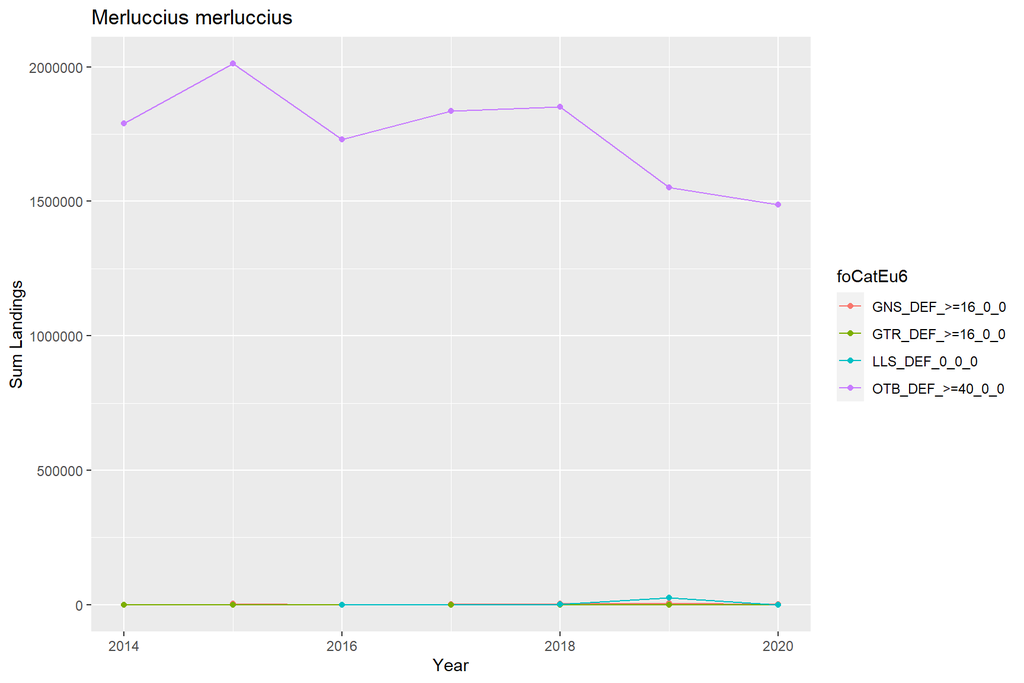